# DATA_621_Blog_4

Euclid Zhang

4/4/2022

# Multinomial Regression

In the last blog, we have showed how to use logistic regression to predict response variable of binary outcome (Yes / No, True / False, or 0 / 1). But what do we do when the response variable is categorical with more than 2 possible outcomes? In this situation, a multinomial regression model should be used.

Multinomial Regression is an extension of the logistic model. It predicts the probabilities of all possible outcomes and classify the the outcome of a case to be the one with the highest probability.

One important factor that we need to be aware about Multinomial Regression is the Independence of Irrelevant Alternatives assumption. What it says is that the ratio of outcome A to outcome B is not affected by the presence of any other outcomes.

# Crop Recommendation

In blog 1 we have showed how to use a linear regression model to help finding how corp yield is affected by the quantity of fertilizer. We can also use a multinomial regression model to recommend the type of crop to be grown based on the soil conditions and the weather of the location.

The data used is from https://www.kaggle.com/datasets/atharvaingle/crop-recommendation-dataset

```r
df <- read.csv("Crop_recommendation.csv", stringsAsFactors = TRUE)
```

The data contains the following fields:

- N: ratio of Nitrogen content in soil
- P: ratio of Phosphorous content in soil
- K: ratio of Potassium content in soil
- temperature: temperature in degree Celsius
- humidity: relative humidity in %
- ph: ph value of the soil
- rainfall: rainfall in mm
- label: the most suitable corp to grow

```r
summary(df)
```

```
##        N                P                K           temperature
##  Min.   :  0.00   Min.   :  5.00   Min.   :  5.00   Min.   : 8.826
##  1st Qu.: 21.00   1st Qu.: 28.00   1st Qu.: 20.00   1st Qu.:22.769
##  Median : 37.00   Median : 51.00   Median : 32.00   Median :25.599
##  Mean   : 50.55   Mean   : 53.36   Mean   : 48.15   Mean   :25.616
##  3rd Qu.: 84.25   3rd Qu.: 68.00   3rd Qu.: 49.00   3rd Qu.:28.562
##  Max.   :140.00   Max.   :145.00   Max.   :205.00   Max.   :43.675
##
##     humidity           ph           rainfall            label
##  Min.   :14.26   Min.   :3.505   Min.   : 20.21   apple    : 100
##  1st Qu.:60.26   1st Qu.:5.972   1st Qu.: 64.55   banana   : 100
##  Median :80.47   Median :6.425   Median : 94.87   blackgram: 100
##  Mean   :71.48   Mean   :6.469   Mean   :103.46   chickpea : 100
##  3rd Qu.:89.95   3rd Qu.:6.924   3rd Qu.:124.27   coconut  : 100
##  Max.   :99.98   Max.   :9.935   Max.   :298.56   coffee   : 100
##                                                   (Other)  :1600
```

The data is already well-prepared, we can go straight building the model.

```r
summary(mulnorm_model)
```

```
## Call:
## multinom(formula = label ~ ., data = df)
##
## Coefficients:
##             (Intercept)             N             P            K temperature
## banana      -0.20922626  0.1053983355  0.1304376378 -0.060401476  0.08919312
## blackgram   -0.97652506  0.0323032773  0.1015516045 -0.101327588  0.07252628
## chickpea     0.21355920  0.0376544224 -0.0014565651 -0.012055129 -0.14900479
## coconut     -0.08021943 -0.0036606218 -0.0481213406 -0.014327994  0.09359918
## coffee      -0.03009158  0.0990409274 -0.0359712287 -0.026879643  0.11880797
## cotton      -0.29561900  0.0976399909  0.0402523682 -0.073425238 -0.22852555
## grapes       0.20150953  0.0268181647 -0.0213785504  0.018624037  0.02769491
## jute        -0.17355656  0.0506766381 -0.0071974188 -0.032810871 -0.09102056
## kidneybeans  0.62539819  0.0507426259  0.1239611788 -0.103129558 -0.02777318
## lentil       0.24036332  0.0008370814  0.1087575120 -0.082533833 -0.12277581
## maize        1.15943479  0.0672147541  0.0533094204 -0.072831653 -0.10539284
## mango        0.50734365  0.0030031089 -0.0193506576 -0.008737119  0.19222513
## mothbeans    0.75479262  0.0104609696  0.0350531146 -0.041336795 -0.02675751
## mungbean    -0.24399663  0.0048065364  0.0814531261 -0.085652585  0.04336749
## muskmelon   -0.07334225  0.0465388207  0.0009831031 -0.013673764  0.04529666
## orange      -0.09583584  0.0066592565 -0.0142530533 -0.115135400 -0.01745664
## papaya      -1.40440750  0.0187414527  0.0435987712 -0.057348478  0.11189354
## pigeonpeas  -0.15887061  0.0227194935  0.1343954296 -0.108132775  0.10471718
## pomegranate  0.33422637  0.0122545732 -0.0340889428 -0.006244764 -0.05238696
## rice        -0.09677686  0.0844508971  0.0118880889 -0.105874781 -0.13896550
## watermelon   0.21641879  0.0567948520 -0.0609079875  0.014202318 -0.06311994
##                  humidity          ph     rainfall
## banana      -0.0485037921 -0.92127895 -0.026886075
## blackgram    0.0244784304  0.07701220 -0.035640454
## chickpea    -0.0581014314  1.57738604 -0.027304303
## coconut      0.1312028305 -1.63770462  0.009652626
## coffee      -0.1408629190  0.51761721  0.001792064
## cotton       0.0108741467  1.02952373 -0.049108613
## grapes      -0.0258635377  1.03349247 -0.074316481
## jute        -0.0013361745  0.38919524  0.005279594
## kidneybeans -0.0902632794  0.49736373 -0.019438778
## lentil       0.0218827634  0.87304498 -0.067127609
## maize       -0.0069113815  0.69247185 -0.038704276
## mango       -0.0362671441  0.07238741 -0.007213563
## mothbeans   -0.0093191348  1.04603059 -0.037094848
```

[output cut: 42 more lines]

```
## lentil      0.2979974 0.011981045
## maize       0.3040638 0.008572637
## mango       0.2890933 0.008259292
## mothbeans   0.2484801 0.007817433
## mungbean    0.3198780 0.009277457
## muskmelon   0.4082126 0.009207957
## orange      0.3018903 0.008839305
## papaya      0.2860763 0.007593759
## pigeonpeas  0.3039943 0.008015614
## pomegranate 0.3104098 0.007826155
## rice        0.4125907 0.011577219
## watermelon  0.3339099 0.008147352
##
## Residual Deviance: 3214.153
## AIC: 3550.153
```

# Conclusion

From the result of our model, holding all other predictor values the same:

- For soil with higher Nitrogen content, it is better to grow Banana, Coffee, or Cotton
- For soil with higher Phosphorous content, it is better to grow Pigeonpeas, Banana, or Kidneybeans
- For soil with higher Potassium content, it is better to grow Grapes, Watermelon, or Apple  
  **apple is not showed in the model because it is the base case, most of other coefficients are less than 0 indicates that they are less recommended to be grown than apple**
- For higher temperature, it is better to grow Mango, Coffee, or Papaya
- For higher humidity, it is better to grow Coconut, Mungbean, or Muskmelon
- For soil with higher ph, it is better to grow Chickpea, Grapes, Cotton or, Mothbeans
- For higher rainfall, it is better to grow Rice, Coconut, or Pigeonpeas

We can check the performance of our model:

```r
xtabs( ~ predict(mulnorm_model) + df$label)
```

```
##                       df$label
## predict(mulnorm_model) apple banana blackgram chickpea coconut coffee cotton
##            apple          98      0         0        0       0      0      0
##            banana          1     99         0        0       0      0      0
##            blackgram       0      1        86        0       0      0      0
##            chickpea        0      0         0       99       0      0      0
##            coconut         0      0         0        0     100      0      0
##            coffee          0      0         0        1       0     86      0
##            cotton          0      0         0        0       0      1    100
##            grapes          0      0         0        0       0      0      0
##            jute            0      0         0        0       0      3      0
##            kidneybeans     0      0         0        0       0      0      0
##            lentil          0      0         0        0       0      0      0
##            maize           0      0         0        0       0      0      0
##            mango           0      0         0        0       0      0      0
##            mothbeans       0      0        14        0       0      0      0
##            mungbean        0      0         0        0       0      0      0
##            muskmelon       1      0         0        0       0      0      0
##            orange          0      0         0        0       0      0      0
##            papaya          0      0         0        0       0      0      0
##            pigeonpeas      0      0         0        0       0      0      0
##            pomegranate     0      0         0        0       0      0      0
##            rice            0      0         0        0       0      8      0
##            watermelon      0      0         0        0       0      2      0
##                       df$label
## predict(mulnorm_model) grapes jute kidneybeans lentil maize mango mothbeans
##            apple            0    0           0      0     0     0         0
##            banana           2    0           0      0     5     0         0
##            blackgram        0    0           0     20    21     0        16
##            chickpea         0    0           0      0     0     0         0
##            coconut          0    0           0      0     0     0         0
##            coffee           0    0           0      0     0     0         0
##            cotton           0    0           0      0    40     0         0
##            grapes          93    0           0      0     0     0         0
##            jute             0   72           0      0     0     0         0
##            kidneybeans      0    0         100      0     0     0         0
##            lentil           0    0           0     65     0     0         0
##            maize            0    0           0      0    31     0         0
##            mango            2    0           0      0     0    97         0
##            mothbeans        0    0           0     15     3     3        74
```

[output cut: 41 more lines]

```
##            grapes         0          0
##            jute           9          0
##            kidneybeans    0          0
##            lentil         0          0
##            maize          0          0
##            mango          0          0
##            mothbeans      0          0
##            mungbean       0          0
##            muskmelon      0         12
##            orange         0          0
##            papaya         2          0
##            pigeonpeas     0          0
##            pomegranate    0          0
##            rice          89          0
##            watermelon     0         85
```

Most of cases are classified correctly, except for maize. For maize, we can see from the following plots that it doesn’t favor any high or low value of the predictors. Therefore, it is not well-recommended by our model in any soil or weather conditions, comparing to other corps.

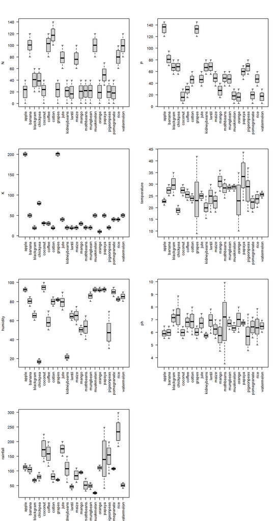

```r
par(mfrow=c(4,2))
plot(N~label,df, las=2, xlab = "")
plot(P~label,df, las=2, xlab = "")
plot(K~label,df, las=2, xlab = "")
plot(temperature~label,df, las=2, xlab = "")
plot(humidity~label,df, las=2, xlab = "")
plot(ph~label,df, las=2, xlab = "")
plot(rainfall~label,df, las=2, xlab = "")
```